# Cassava_Yield_Data_Analysis

Group 3: Mugisha Timothy – S25B38/041, Lamara Megan – M25B38/005, Nagasha Erwin – M25B38/038, Jjengo Timothy – S25B38/017, Daniella Namugga – M25B38/007, Ndambiire Harry – M25B38/030

25-09-2026

```r
knitr::opts_knit$set(root.dir = "T:/MUGISHA TIMOTHY NAABAASA/YEAR 2 SEMESTER 1/Big Data Analytics and Technologies/Assignments/Group_3")
knitr::opts_chunk$set(echo = TRUE, warning = FALSE, message = FALSE)
```

#Install and run libraries

```r
# Install once
#install.packages(c("tidyverse","readxl","skimr","janitor","GGally","rstatix","car","patchwork"))
#install.packages("tinytex")
#tinytex::install_tinytex()
# Load every session
library(tidyverse)
library(readxl)
library(skimr)
library(janitor)
library(GGally)
library(rstatix)
library(car)
library(patchwork)
```

```r
df <- read_excel("Cassava_Yield_Data.xlsx")
```

```r
df <- clean_names(df)
```

```r
df
```

```
## # A tibble: 115 × 20
##     sesn  locn block   rep tillage fer_t plants_harvested no_bigtubers
##    <dbl> <dbl> <dbl> <dbl> <chr>   <chr>            <dbl>        <dbl>
##  1     2     1     1     1 conv    F2150               28            0
##  2     2     1     1     1 conv    F1100               28            0
##  3     2     1     1     1 conv    F3200               28            2
##  4     2     1     1     1 conv    F5300               28            6
##  5     2     1     1     1 conv    F4250               28            3
##  6     2     1     2     2 conv    F5300               28            6
##  7     2     1     2     2 conv    F3200               28            0
##  8     2     1     2     2 conv    F4250               28            0
##  9     2     1     2     2 conv    F1100               28            1
## 10     2     1     2     2 conv    F2150               28            1
## # ℹ 105 more rows
## # ℹ 12 more variables: weigh_bigtubers <dbl>, no_mediumtubers <dbl>,
## #   weight_mediumtubers <dbl>, no_smalltubers <dbl>, weight_smalltubers <dbl>,
## #   totaltuberno <dbl>, av_tubers_plant <dbl>, total_tubweight <dbl>,
## #   plotsize <dbl>, hec <dbl>, total_weightperhectare <dbl>,
## #   total_tuberper_hectare <dbl>
```

DATA EXPLORATION,INSPECTION,AND CLEANING

#Dataset understanding

1. str()

Displays variable type and sample values.

```r
str(df)
```

```
## tibble [115 × 20] (S3: tbl_df/tbl/data.frame)
##  $ sesn                  : num [1:115] 2 2 2 2 2 2 2 2 2 2 ...
##  $ locn                  : num [1:115] 1 1 1 1 1 1 1 1 1 1 ...
##  $ block                 : num [1:115] 1 1 1 1 1 2 2 2 2 2 ...
##  $ rep                   : num [1:115] 1 1 1 1 1 2 2 2 2 2 ...
##  $ tillage               : chr [1:115] "conv" "conv" "conv" "conv" ...
##  $ fer_t                 : chr [1:115] "F2150" "F1100" "F3200" "F5300" ...
##  $ plants_harvested      : num [1:115] 28 28 28 28 28 28 28 28 28 28 ...
##  $ no_bigtubers          : num [1:115] 0 0 2 6 3 6 0 0 1 1 ...
##  $ weigh_bigtubers       : num [1:115] 0 0 0.2 0.7 0.3 0.5 0 0 0.2 0.1 ...
##  $ no_mediumtubers       : num [1:115] 61 110 115 60 82 65 91 72 64 56 ...
##  $ weight_mediumtubers   : num [1:115] 2.5 4.6 5.2 2.7 3.4 2.7 3.9 3.5 2.6 2.5 ...
##  $ no_smalltubers        : num [1:115] 319 260 319 303 332 299 289 246 305 308 ...
##  $ weight_smalltubers    : num [1:115] 4.7 4 4.4 4.8 4.7 4.5 4.8 4.6 5.4 4.5 ...
##  $ totaltuberno          : num [1:115] 380 370 436 369 417 370 380 318 370 365 ...
##  $ av_tubers_plant       : num [1:115] 13.6 13.2 15.6 13.2 14.9 ...
##  $ total_tubweight       : num [1:115] 7.2 8.6 9.8 8.2 8.4 7.7 8.7 8.1 8.2 7.1 ...
##  $ plotsize              : num [1:115] 5.3 5.3 5.3 5.3 5.3 5.3 5.3 5.3 5.3 5.3 ...
##  $ hec                   : num [1:115] 10000 10000 10000 10000 10000 10000 10000 10000 10000 10000 ...
##  $ total_weightperhectare: num [1:115] 13585 16226 18491 15472 15849 ...
##  $ total_tuberper_hectare: num [1:115] 716981 698113 822642 696226 786792 ...
```

2. dim()

Returns rows and columns.

```r
dim(df)
```

```
## [1] 115  20
```

3. names()

Lists variable names.

```r
names(df)
```

```
##  [1] "sesn"                   "locn"                   "block"
##  [4] "rep"                    "tillage"                "fer_t"
##  [7] "plants_harvested"       "no_bigtubers"           "weigh_bigtubers"
## [10] "no_mediumtubers"        "weight_mediumtubers"    "no_smalltubers"
## [13] "weight_smalltubers"     "totaltuberno"           "av_tubers_plant"
## [16] "total_tubweight"        "plotsize"               "hec"
## [19] "total_weightperhectare" "total_tuberper_hectare"
```

4. glimpse()

A tidyverse version of str() that’s easier to read.

```r
glimpse(df)
```

```
## Rows: 115
## Columns: 20
## $ sesn                   <dbl> 2, 2, 2, 2, 2, 2, 2, 2, 2, 2, 2, 2, 2, 2, 2, 2,…
## $ locn                   <dbl> 1, 1, 1, 1, 1, 1, 1, 1, 1, 1, 1, 1, 1, 1, 1, 1,…
## $ block                  <dbl> 1, 1, 1, 1, 1, 2, 2, 2, 2, 2, 3, 3, 3, 3, 3, 1,…
## $ rep                    <dbl> 1, 1, 1, 1, 1, 2, 2, 2, 2, 2, 3, 3, 3, 3, 3, 1,…
## $ tillage                <chr> "conv", "conv", "conv", "conv", "conv", "conv",…
## $ fer_t                  <chr> "F2150", "F1100", "F3200", "F5300", "F4250", "F…
## $ plants_harvested       <dbl> 28, 28, 28, 28, 28, 28, 28, 28, 28, 28, 28, 28,…
## $ no_bigtubers           <dbl> 0, 0, 2, 6, 3, 6, 0, 0, 1, 1, 4, 3, 3, 0, 0, 1,…
## $ weigh_bigtubers        <dbl> 0.0, 0.0, 0.2, 0.7, 0.3, 0.5, 0.0, 0.0, 0.2, 0.…
## $ no_mediumtubers        <dbl> 61, 110, 115, 60, 82, 65, 91, 72, 64, 56, 63, 9…
## $ weight_mediumtubers    <dbl> 2.5, 4.6, 5.2, 2.7, 3.4, 2.7, 3.9, 3.5, 2.6, 2.…
## $ no_smalltubers         <dbl> 319, 260, 319, 303, 332, 299, 289, 246, 305, 30…
## $ weight_smalltubers     <dbl> 4.7, 4.0, 4.4, 4.8, 4.7, 4.5, 4.8, 4.6, 5.4, 4.…
## $ totaltuberno           <dbl> 380, 370, 436, 369, 417, 370, 380, 318, 370, 36…
## $ av_tubers_plant        <dbl> 13.571429, 13.214286, 15.571429, 13.178571, 14.…
## $ total_tubweight        <dbl> 7.2, 8.6, 9.8, 8.2, 8.4, 7.7, 8.7, 8.1, 8.2, 7.…
## $ plotsize               <dbl> 5.3, 5.3, 5.3, 5.3, 5.3, 5.3, 5.3, 5.3, 5.3, 5.…
## $ hec                    <dbl> 10000, 10000, 10000, 10000, 10000, 10000, 10000…
## $ total_weightperhectare <dbl> 13584.906, 16226.415, 18490.566, 15471.698, 158…
## $ total_tuberper_hectare <dbl> 716981.1, 698113.2, 822641.5, 696226.4, 786792.…
```

Next, we will convert certain types of variables inot the correct data type. R sometimes imports categorical variables as numerical values or text. Statistical tests require them to be factors. We use factors for conversion because factors tell R to treat variables as categories instead of numeric variables. Doing this will enable us to use statistical methods like ANOVA, chi-square tests, and grouped visualizations.

```r
df <- df%>% mutate(sesn = as.factor(sesn), locn=as.factor(locn), block=as.factor(block), rep=as.factor(rep), tillage=as.factor(tillage), fer_t=as.factor(fer_t))

glimpse(df)
```

```
## Rows: 115
## Columns: 20
## $ sesn                   <fct> 2, 2, 2, 2, 2, 2, 2, 2, 2, 2, 2, 2, 2, 2, 2, 2,…
## $ locn                   <fct> 1, 1, 1, 1, 1, 1, 1, 1, 1, 1, 1, 1, 1, 1, 1, 1,…
## $ block                  <fct> 1, 1, 1, 1, 1, 2, 2, 2, 2, 2, 3, 3, 3, 3, 3, 1,…
## $ rep                    <fct> 1, 1, 1, 1, 1, 2, 2, 2, 2, 2, 3, 3, 3, 3, 3, 1,…
## $ tillage                <fct> conv, conv, conv, conv, conv, conv, conv, conv,…
## $ fer_t                  <fct> F2150, F1100, F3200, F5300, F4250, F5300, F3200…
## $ plants_harvested       <dbl> 28, 28, 28, 28, 28, 28, 28, 28, 28, 28, 28, 28,…
## $ no_bigtubers           <dbl> 0, 0, 2, 6, 3, 6, 0, 0, 1, 1, 4, 3, 3, 0, 0, 1,…
## $ weigh_bigtubers        <dbl> 0.0, 0.0, 0.2, 0.7, 0.3, 0.5, 0.0, 0.0, 0.2, 0.…
## $ no_mediumtubers        <dbl> 61, 110, 115, 60, 82, 65, 91, 72, 64, 56, 63, 9…
## $ weight_mediumtubers    <dbl> 2.5, 4.6, 5.2, 2.7, 3.4, 2.7, 3.9, 3.5, 2.6, 2.…
## $ no_smalltubers         <dbl> 319, 260, 319, 303, 332, 299, 289, 246, 305, 30…
## $ weight_smalltubers     <dbl> 4.7, 4.0, 4.4, 4.8, 4.7, 4.5, 4.8, 4.6, 5.4, 4.…
## $ totaltuberno           <dbl> 380, 370, 436, 369, 417, 370, 380, 318, 370, 36…
## $ av_tubers_plant        <dbl> 13.571429, 13.214286, 15.571429, 13.178571, 14.…
## $ total_tubweight        <dbl> 7.2, 8.6, 9.8, 8.2, 8.4, 7.7, 8.7, 8.1, 8.2, 7.…
## $ plotsize               <dbl> 5.3, 5.3, 5.3, 5.3, 5.3, 5.3, 5.3, 5.3, 5.3, 5.…
## $ hec                    <dbl> 10000, 10000, 10000, 10000, 10000, 10000, 10000…
## $ total_weightperhectare <dbl> 13584.906, 16226.415, 18490.566, 15471.698, 158…
## $ total_tuberper_hectare <dbl> 716981.1, 698113.2, 822641.5, 696226.4, 786792.…
```

#Descriptive Statistics

#> The skim function produces mean, median, standard deviation, min, max, missing values, and histograms inside the console

```r
skim(df)
```

Data summary

| Name | df |
| --- | --- |
| Number of rows | 115 |
| Number of columns | 20 |
| _______________________ |  |
| Column type frequency: |  |
| factor | 6 |
| numeric | 14 |
| ________________________ |  |
| Group variables | None |

**Variable type: factor**

| skim_variable | n_missing | complete_rate | ordered | n_unique | top_counts |
| --- | --- | --- | --- | --- | --- |
| sesn | 0 | 1 | FALSE | 2 | 2: 60, 1: 55 |
| locn | 0 | 1 | FALSE | 2 | 2: 60, 1: 55 |
| block | 0 | 1 | FALSE | 3 | 2: 40, 3: 40, 1: 35 |
| rep | 0 | 1 | FALSE | 3 | 2: 40, 3: 40, 1: 35 |
| tillage | 0 | 1 | FALSE | 2 | con: 60, min: 55 |
| fer_t | 0 | 1 | FALSE | 5 | F11: 23, F21: 23, F32: 23, F42: 23 |

**Variable type: numeric**

| skim_variable | n_missing | complete_rate | mean | sd | p0 | p25 | p50 | p75 | p100 | hist |
| --- | --- | --- | --- | --- | --- | --- | --- | --- | --- | --- |
| plants_harvested | 0 | 1 | 18.57 | 6.44 | 5.00 | 14.00 | 18.00 | 28.00 | 28.00 | ▂▆▇▅▇ |
| no_bigtubers | 0 | 1 | 4.00 | 7.37 | 0.00 | 0.00 | 0.00 | 5.50 | 41.00 | ▇▁▁▁▁ |
| weigh_bigtubers | 0 | 1 | 0.61 | 1.17 | 0.00 | 0.00 | 0.00 | 0.70 | 7.00 | ▇▁▁▁▁ |
| no_mediumtubers | 0 | 1 | 49.52 | 29.92 | 0.00 | 26.50 | 44.00 | 65.50 | 126.00 | ▆▇▆▂▂ |
| weight_mediumtubers | 0 | 1 | 2.77 | 1.77 | 0.00 | 1.30 | 2.50 | 3.95 | 8.10 | ▇▇▃▂▁ |
| no_smalltubers | 0 | 1 | 146.25 | 87.35 | 37.00 | 84.00 | 109.00 | 221.00 | 376.00 | ▇▅▁▃▁ |
| weight_smalltubers | 0 | 1 | 2.51 | 1.30 | 0.50 | 1.50 | 2.10 | 3.60 | 5.40 | ▅▇▃▃▃ |
| totaltuberno | 0 | 1 | 199.77 | 102.56 | 57.00 | 115.50 | 179.00 | 273.50 | 443.00 | ▇▆▅▃▂ |
| av_tubers_plant | 0 | 1 | 10.53 | 3.25 | 3.80 | 8.03 | 10.67 | 12.97 | 19.20 | ▃▆▇▅▁ |
| total_tubweight | 0 | 1 | 5.90 | 3.04 | 1.00 | 3.40 | 6.00 | 8.15 | 14.10 | ▇▆▇▂▁ |
| plotsize | 0 | 1 | 4.49 | 0.49 | 4.20 | 4.20 | 4.20 | 5.30 | 5.30 | ▇▁▁▁▃ |
| hec | 0 | 1 | 10000.00 | 0.00 | 10000.00 | 10000.00 | 10000.00 | 10000.00 | 10000.00 | ▁▁▇▁▁ |
| total_weightperhectare | 0 | 1 | 13094.34 | 6896.72 | 2380.95 | 8095.24 | 11904.76 | 16421.83 | 33571.43 | ▇▇▆▂▁ |
| total_tuberper_hectare | 0 | 1 | 431822.34 | 184839.31 | 135714.29 | 275000.00 | 419047.62 | 589285.71 | 835849.06 | ▇▇▇▆▃ |

**Observation**: The descriptive statistics show the central tendency, spread, minimum and maximum values, and distribution of each numeric variable. Yield-related variables exhibit noticeable variability across cassava plots, suggesting differences in field performance among treatments and locations.

#MISSING VALUES

```r
round(colMeans(is.na(df))*100,2)
```

```
##                   sesn                   locn                  block
##                      0                      0                      0
##                    rep                tillage                  fer_t
##                      0                      0                      0
##       plants_harvested           no_bigtubers        weigh_bigtubers
##                      0                      0                      0
##        no_mediumtubers    weight_mediumtubers         no_smalltubers
##                      0                      0                      0
##     weight_smalltubers           totaltuberno        av_tubers_plant
##                      0                      0                      0
##        total_tubweight               plotsize                    hec
##                      0                      0                      0
## total_weightperhectare total_tuberper_hectare
##                      0                      0
```

**Observation**: As shown, the cassava dataset variables have no missing values, meaning we can proceed with analysis without applying imputation or deleting observations. The dataset is complete, and no information was lost due to missing-value handling.

#DETECT DUPLICATES

```r
duplicate_rows <- duplicated(df)
sum(duplicate_rows)
```

```
## [1] 0
```

```r
df[duplicate_rows, ]
```

```
## # A tibble: 0 × 20
## # ℹ 20 variables: sesn <fct>, locn <fct>, block <fct>, rep <fct>,
## #   tillage <fct>, fer_t <fct>, plants_harvested <dbl>, no_bigtubers <dbl>,
## #   weigh_bigtubers <dbl>, no_mediumtubers <dbl>, weight_mediumtubers <dbl>,
## #   no_smalltubers <dbl>, weight_smalltubers <dbl>, totaltuberno <dbl>,
## #   av_tubers_plant <dbl>, total_tubweight <dbl>, plotsize <dbl>, hec <dbl>,
## #   total_weightperhectare <dbl>, total_tuberper_hectare <dbl>
```

**Observation**: No duplicate rows were identified in the dataset. Every observation corresponds to a unique cassava field record. Duplicate removal is not required before analysis.

#DISTRIBUTION OF ALL VARIABLES

1. Numerical Variables

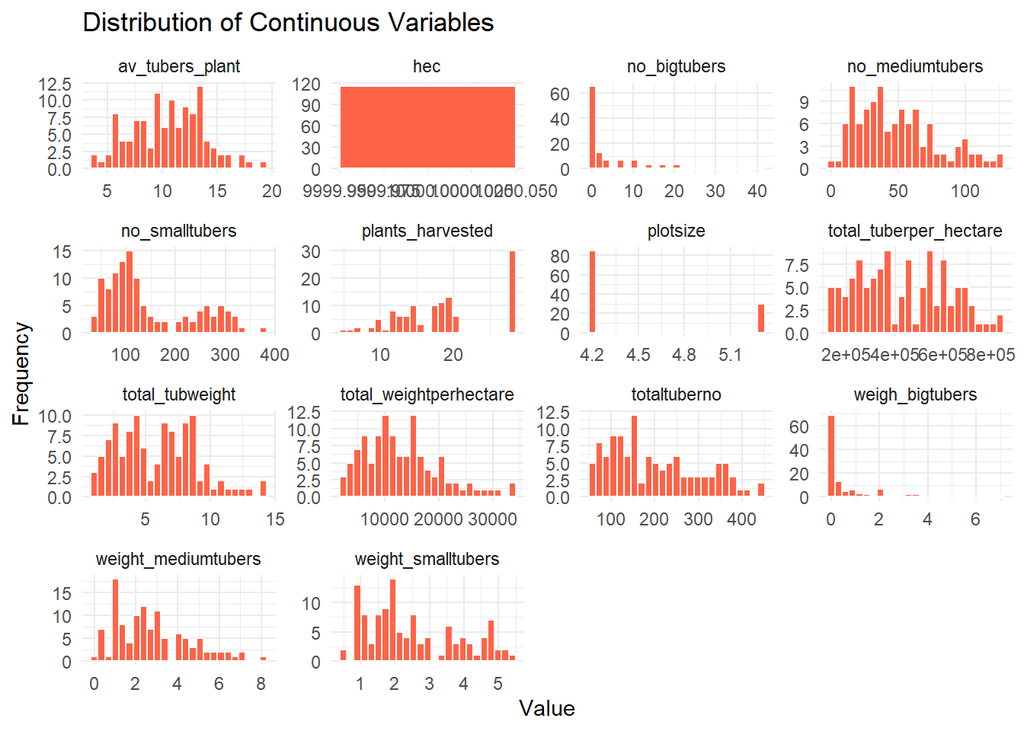

```r
numeric_vars <- df %>% select(where(is.numeric))

numeric_vars %>% pivot_longer(cols = everything()) %>% ggplot(aes(value)) +
  geom_histogram(bins = 25, fill = "tomato",color = "white") +
  facet_wrap(~name, scales = "free") +
  labs(title = "Distribution of Continuous Variables",x = "Value",y = "Frequency") +theme_minimal()
```

2.Categorical Variables

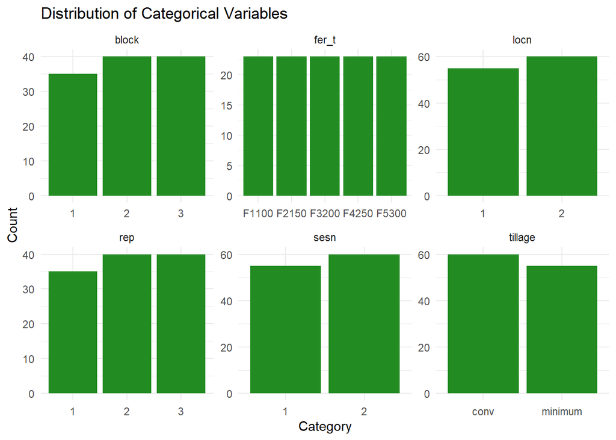

```r
categorical_vars <- df %>% select(where(is.factor))

categorical_vars %>% pivot_longer(cols = everything()) %>% ggplot(aes(value)) + geom_bar(fill = "forestgreen") +
  facet_wrap(~name, scales = "free") +
  labs(title = "Distribution of Categorical Variables", x = "Category", y = "Count") +theme_minimal()
```

**Observation**: The categorical bar charts show the frequency distribution of each category. The observations appear reasonably balanced across seasons, tillage methods, fertilizer treatments, and locations, reducing the likelihood that one category dominates the analysis. Thus the categorical variables contain sufficient observations in each category for comparative statistical testing and visualization.

#DETECT OUTLIERS

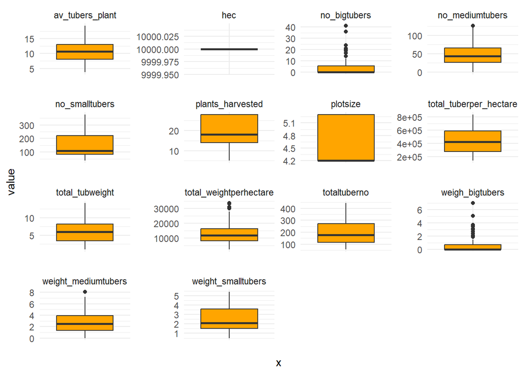

```r
numeric_vars %>% pivot_longer(cols = everything()) %>% ggplot(aes(x="", y=value)) + geom_boxplot(fill = "orange") +
  facet_wrap(~name, scales="free") + theme_minimal()
```

**Observation**: The boxplots identify a few observations lying beyond the whiskers in several yield variables. These values are statistically classified as outliers using the 1.5 × IQR rule, but they may represent genuine high- or low-performing cassava plots rather than recording errors. Basically, outliers exist in the dataset and should be managed carefully without immediately removing valid agricultural observations.

#TRANSFORMATION OF THE DATA WITH OUTLIERS

1. Winsorization - This caps extreme values instead of deleting them.

```r
df_clean <- df

winsorize <- function(x){

  q1 <- quantile(x,0.25,na.rm=TRUE)
  q3 <- quantile(x,0.75,na.rm=TRUE)

  iqr <- q3-q1

  lower <- q1 - 1.5*iqr
  upper <- q3 + 1.5*iqr

  x <- ifelse(x<lower, lower, x)
  x <- ifelse(x>upper, upper, x)

  x
}

df_clean <- df_clean %>% mutate(across(where(is.numeric), winsorize))
```

Note: Another option would be to remove outliers, but in this case it will not be necessary.

#VERIFY CLEANED WORK

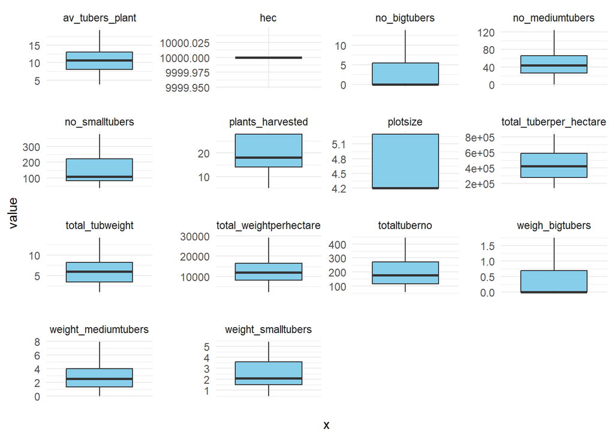

```r
df_clean %>% select(where(is.numeric)) %>% pivot_longer(cols = everything()) %>% ggplot(aes("", value))+
  geom_boxplot(fill="skyblue") + facet_wrap(~name, scales="free")+
  theme_minimal()
```

**Observation**: After winsorization, extreme values were reduced while preserving all observations.

TESTING RELATIONSHIPS

#1.a) TWO CONTINUOUS VARIABLES (total_weightperhectare, total_tuberper_hectare)

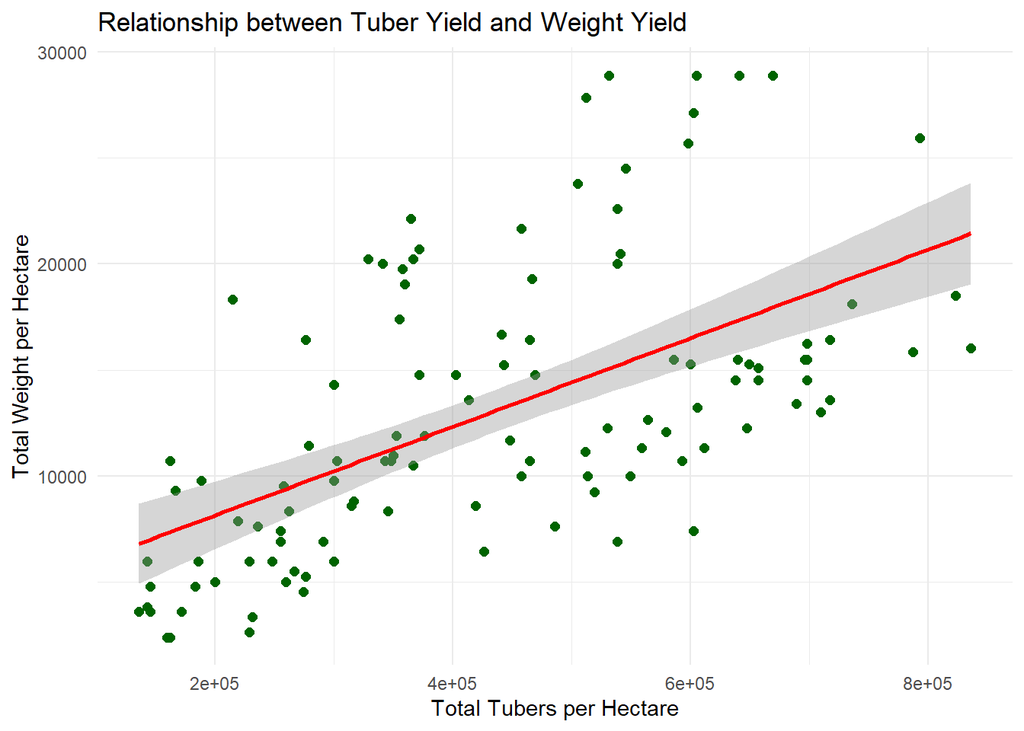

```r
ggplot(df_clean, aes(x = total_tuberper_hectare, y = total_weightperhectare)) + geom_point(color = "darkgreen", size = 2) +
  geom_smooth(method = "lm", se = TRUE, color = "red") +

  theme_minimal() +

  labs(title = "Relationship between Tuber Yield and Weight Yield", x = "Total Tubers per Hectare",
       y = "Total Weight per Hectare")
```

#b) Carry out Normality test

```r
shapiro.test(df_clean$total_weightperhectare)
```

```
##
##  Shapiro-Wilk normality test
##
## data:  df_clean$total_weightperhectare
## W = 0.95754, p-value = 0.001085
```

```r
shapiro.test(df_clean$total_tuberper_hectare)
```

```
##
##  Shapiro-Wilk normality test
##
## data:  df_clean$total_tuberper_hectare
## W = 0.96164, p-value = 0.002264
```

**Observation**: Both variables violate normality, so Spearman correlation is appropriate.

#c) Carry out Spearman Correlation test

```r
cor.test(df_clean$total_weightperhectare, df_clean$total_tuberper_hectare, method = "spearman")
```

```
##
##  Spearman's rank correlation rho
##
## data:  df_clean$total_weightperhectare and df_clean$total_tuberper_hectare
## S = 88935, p-value = 4.301e-15
## alternative hypothesis: true rho is not equal to 0
## sample estimates:
##       rho
## 0.6491151
```

**Deduction**: The scatter plot shows a positive monotonic relationship. Spearman’s rho is about **0.649** with **p < 0.001**, indicating a statistically significant moderate-to-strong positive relationship.

#2.a) CONTINUOUS VARIABLE vs CATEGORICAL VARIABLE (total_weightperhectare, tillage(conv, minimum))

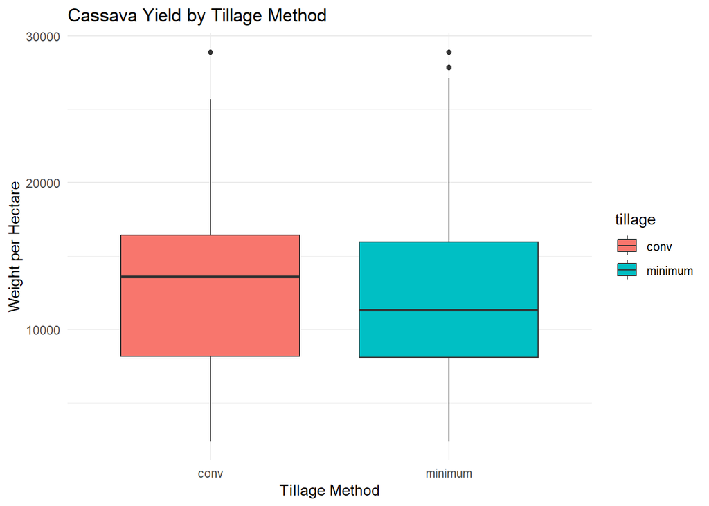

```r
ggplot(df_clean,aes(x = tillage, y = total_weightperhectare, fill = tillage))+

  geom_boxplot()+

  theme_minimal()+

  labs(title="Cassava Yield by Tillage Method", x="Tillage Method", y="Weight per Hectare")
```

**Observation**: Why are there still outliers after winsorization? Winsorization caps extreme values but does not guarantee that all observations fall inside the boxplot whiskers. Boxplots use the 1.5×IQR rule, so some observations remain statistical outliers despite being valid measurements.

#b) Check for normality

```r
by(df_clean$total_weightperhectare, df_clean$tillage, shapiro.test)
```

```
## df_clean$tillage: conv
##
##  Shapiro-Wilk normality test
##
## data:  dd[x, ]
## W = 0.9558, p-value = 0.02941
##
## ------------------------------------------------------------
## df_clean$tillage: minimum
##
##  Shapiro-Wilk normality test
##
## data:  dd[x, ]
## W = 0.94144, p-value = 0.009788
```

**Observation**: Both variables violate normality, so Man-Whitney U test is appropriate.

#b) Carry out the Man-Whitney U test (because the categorical variable has only two groups)

```r
wilcox.test(total_weightperhectare ~ tillage, data = df_clean)
```

```
##
##  Wilcoxon rank sum test with continuity correction
##
## data:  total_weightperhectare by tillage
## W = 1777, p-value = 0.4787
## alternative hypothesis: true location shift is not equal to 0
```

#3.a) 2 CATEGORICAL VARIABLES (tillage, fert)

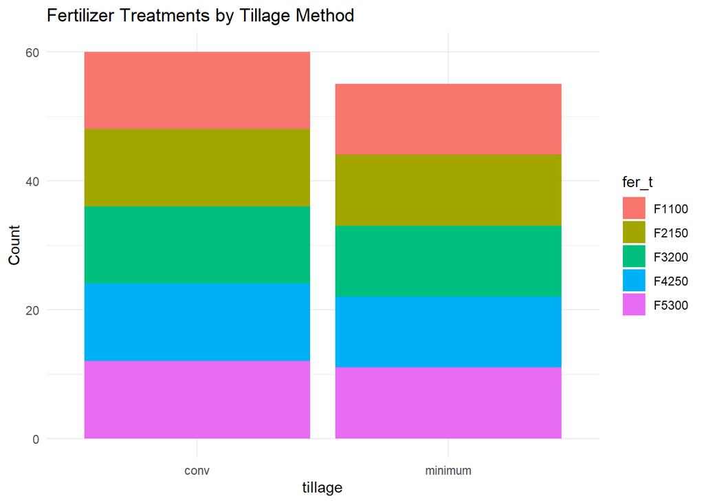

```r
ggplot(df_clean, aes(x=tillage, fill=fer_t)) + geom_bar(position="stack")+

  labs(title="Fertilizer Treatments by Tillage Method", y="Count")+

  theme_minimal()
```

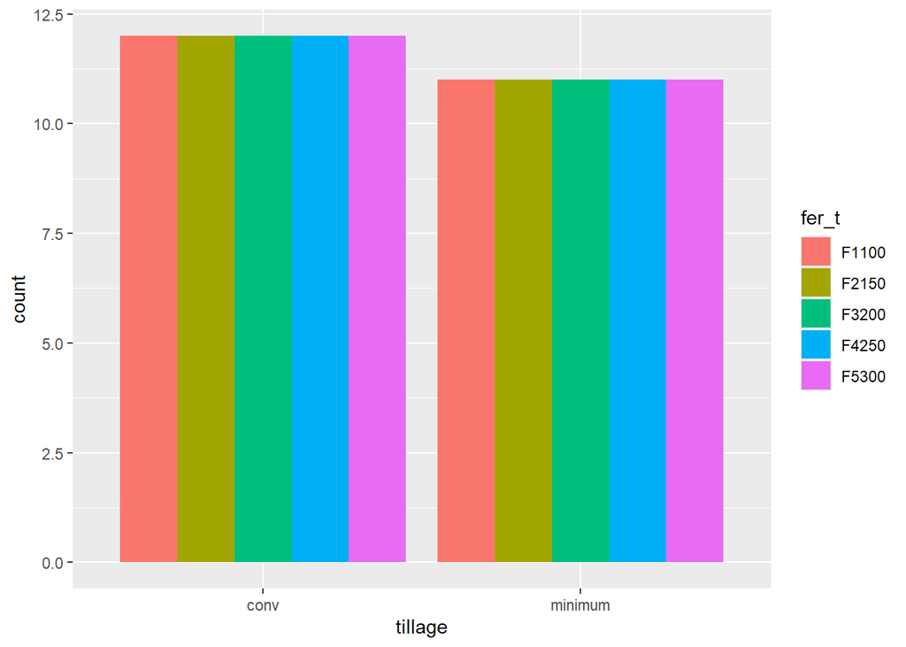

```r
ggplot(df_clean, aes(tillage, fill=fer_t)) + geom_bar(position="dodge")
```

#b) Carry out the Chi-square test (tests independence between 2 categorical variables)

```r
tbl <- table(df_clean$tillage, df_clean$fer_t)
chisq.test(tbl)
```

```
##
##  Pearson's Chi-squared test
##
## data:  tbl
## X-squared = 0, df = 4, p-value = 1
```

**DEDUCTION**: The stacked and grouped bar charts indicate fertilizer treatments are distributed similarly across conventional and minimum tillage methods. No treatment appears concentrated within a single tillage category. The Chi-square test produced **p = 1.00**, showing no statistically significant association between tillage method and fertilizer treatment. The observed frequencies are consistent with random variation rather than dependence.

RECOMMENDATIONS

#1. Does fertilizer application affect the projected “TotalWeightperhectare” and the “TotalTuberperHectare”

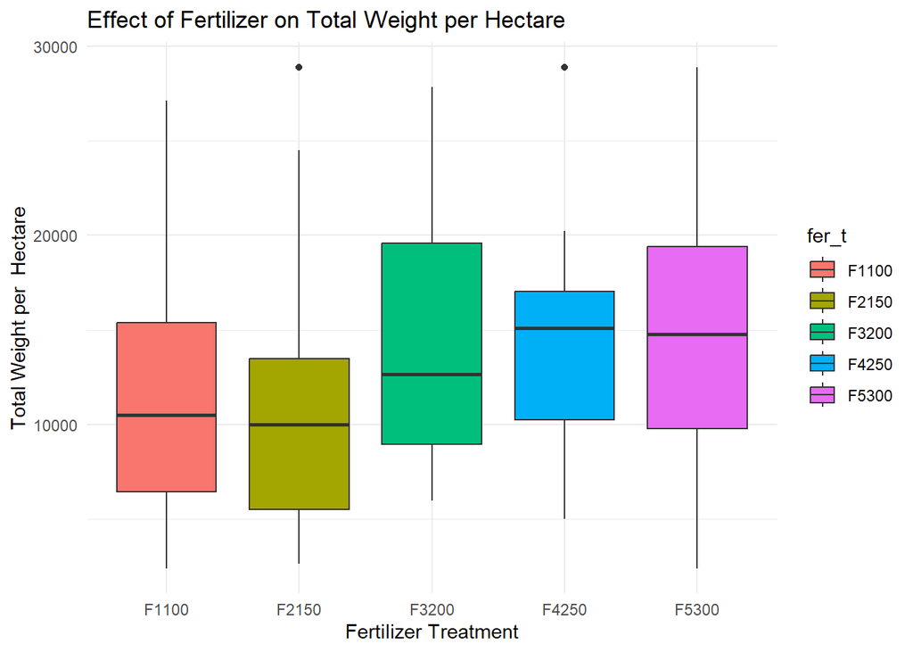

```r
ggplot(df_clean, aes(x = fer_t, y = total_weightperhectare, fill = fer_t)) +
    geom_boxplot() +
    labs(title = "Effect of Fertilizer on Total Weight per Hectare", x = "Fertilizer Treatment",
         y = "Total Weight per  Hectare")+
    theme_minimal()
```

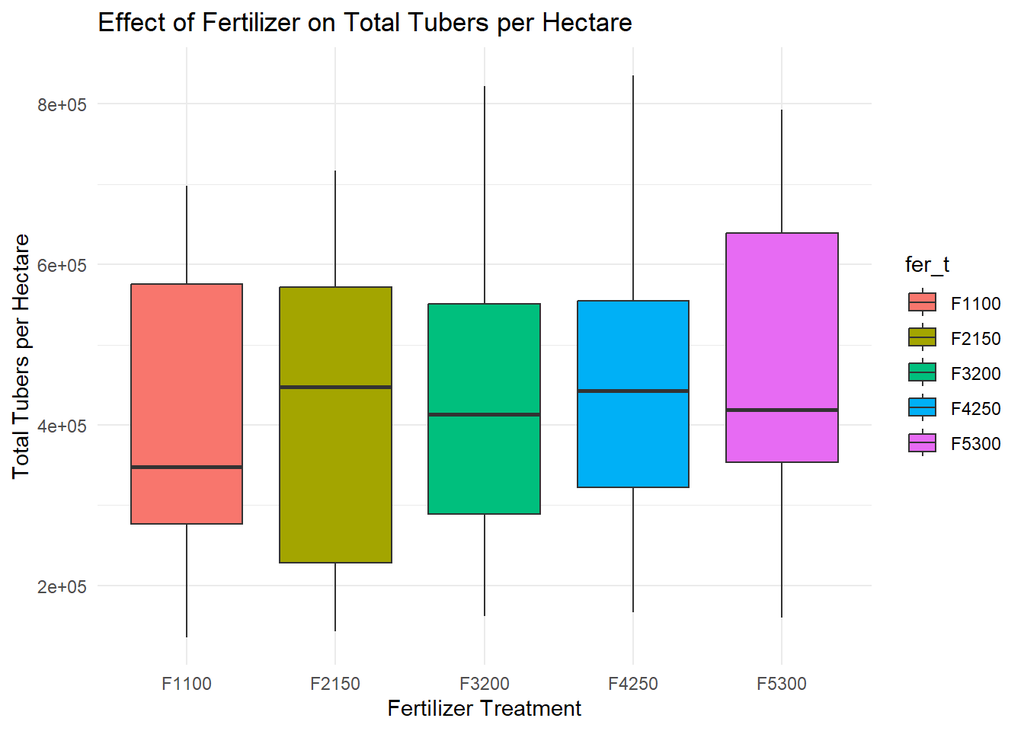

```r
ggplot(df_clean, aes(x = fer_t, y = total_tuberper_hectare, fill = fer_t)) +
    geom_boxplot() +
    labs(title = "Effect of Fertilizer on Total Tubers per Hectare", x = "Fertilizer Treatment",
         y = "Total Tubers per Hectare") +
    theme_minimal()
```

#Check for normality

```r
by(df_clean$total_weightperhectare, df$fer_t, shapiro.test)
```

```
## df$fer_t: F1100
##
##  Shapiro-Wilk normality test
##
## data:  dd[x, ]
## W = 0.9391, p-value = 0.1719
##
## ------------------------------------------------------------
## df$fer_t: F2150
##
##  Shapiro-Wilk normality test
##
## data:  dd[x, ]
## W = 0.88044, p-value = 0.01021
##
## ------------------------------------------------------------
## df$fer_t: F3200
##
##  Shapiro-Wilk normality test
##
## data:  dd[x, ]
## W = 0.92258, p-value = 0.07568
##
## ------------------------------------------------------------
## df$fer_t: F4250
##
##  Shapiro-Wilk normality test
##
## data:  dd[x, ]
## W = 0.93071, p-value = 0.1133
##
## ------------------------------------------------------------
## df$fer_t: F5300
##
##  Shapiro-Wilk normality test
##
## data:  dd[x, ]
## W = 0.97425, p-value = 0.7893
```

```r
by(df_clean$total_tuberper_hectare, df$fer_t, shapiro.test)
```

```
## df$fer_t: F1100
##
##  Shapiro-Wilk normality test
##
## data:  dd[x, ]
## W = 0.9191, p-value = 0.06372
##
## ------------------------------------------------------------
## df$fer_t: F2150
##
##  Shapiro-Wilk normality test
##
## data:  dd[x, ]
## W = 0.89411, p-value = 0.01915
##
## ------------------------------------------------------------
## df$fer_t: F3200
##
##  Shapiro-Wilk normality test
##
## data:  dd[x, ]
## W = 0.96643, p-value = 0.6042
##
## ------------------------------------------------------------
## df$fer_t: F4250
##
##  Shapiro-Wilk normality test
##
## data:  dd[x, ]
## W = 0.95772, p-value = 0.4189
##
## ------------------------------------------------------------
## df$fer_t: F5300
##
##  Shapiro-Wilk normality test
##
## data:  dd[x, ]
## W = 0.94154, p-value = 0.1939
```

```r
kruskal_weight<-kruskal.test(total_weightperhectare ~ fer_t, data=df_clean)
kruskal_weight
```

```
##
##  Kruskal-Wallis rank sum test
##
## data:  total_weightperhectare by fer_t
## Kruskal-Wallis chi-squared = 9.9918, df = 4, p-value = 0.04057
```

```r
kruskal_tubers<-kruskal.test(total_tuberper_hectare ~ fer_t, data=df_clean)
kruskal_tubers
```

```
##
##  Kruskal-Wallis rank sum test
##
## data:  total_tuberper_hectare by fer_t
## Kruskal-Wallis chi-squared = 1.6416, df = 4, p-value = 0.8013
```

**DEDUCTION**: The fertilizer boxplots show different median yields across treatments. Kruskal-Wallis returned **p ≈ 0.041** on total weight per hectare, indicating fertilizer treatment has a significant effect on cassava yield.

#2. Does the tillage method (“conv” and “minimum”) affect the projected “TotalWeightperhectare” and “TotalTuberperHectare”

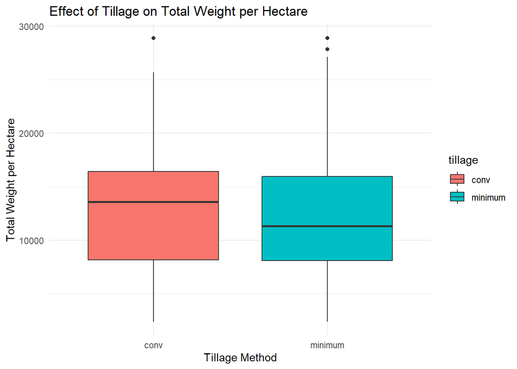

```r
ggplot(df_clean, aes(x = tillage, y = total_weightperhectare, fill = tillage)) +
  geom_boxplot() +
  labs(title = "Effect of Tillage on Total Weight per Hectare", x = "Tillage Method", y = "Total Weight per Hectare") +
  theme_minimal()
```

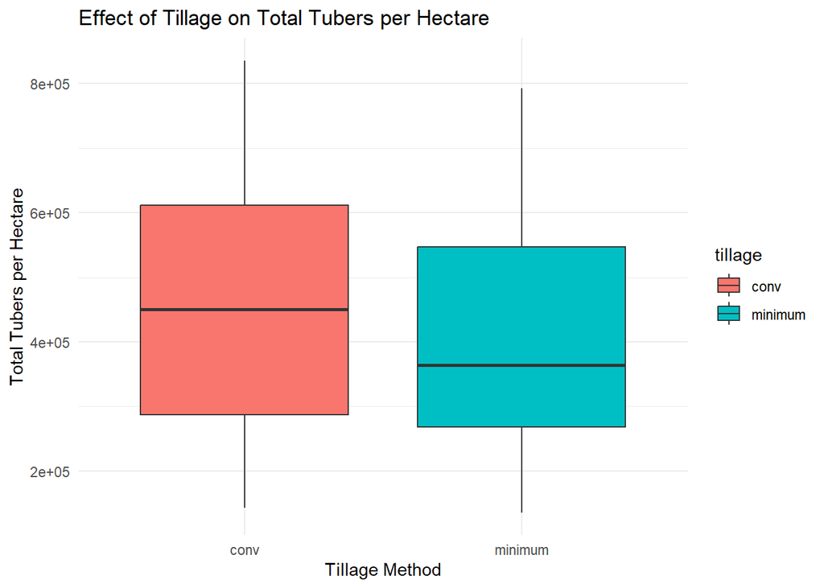

```r
ggplot(df_clean, aes(x = tillage, y = total_tuberper_hectare, fill = tillage)) +
  geom_boxplot() +
  labs(title = "Effect of Tillage on Total Tubers per Hectare", x = "Tillage Method", y = "Total Tubers per Hectare") +
  theme_minimal()
```

```r
df_clean %>%
  group_by(tillage) %>%
  summarise(
    mean_weight = mean(total_weightperhectare, na.rm = TRUE),
    sd_weight = sd(total_weightperhectare, na.rm = TRUE),
    mean_tubers = mean(total_tuberper_hectare, na.rm = TRUE),
    sd_tubers = sd(total_tuberper_hectare, na.rm = TRUE)
  )
```

```
## # A tibble: 2 × 5
##   tillage mean_weight sd_weight mean_tubers sd_tubers
##   <fct>         <dbl>     <dbl>       <dbl>     <dbl>
## 1 conv         13289.     6475.     454506.   196561.
## 2 minimum      12664.     6822.     407077.   169464.
```

#Check normality

```r
by(df_clean$total_weightperhectare, df$tillage, shapiro.test)
```

```
## df$tillage: conv
##
##  Shapiro-Wilk normality test
##
## data:  dd[x, ]
## W = 0.9558, p-value = 0.02941
##
## ------------------------------------------------------------
## df$tillage: minimum
##
##  Shapiro-Wilk normality test
##
## data:  dd[x, ]
## W = 0.94144, p-value = 0.009788
```

```r
by(df_clean$total_tuberper_hectare, df$tillage, shapiro.test)
```

```
## df$tillage: conv
##
##  Shapiro-Wilk normality test
##
## data:  dd[x, ]
## W = 0.95667, p-value = 0.03242
##
## ------------------------------------------------------------
## df$tillage: minimum
##
##  Shapiro-Wilk normality test
##
## data:  dd[x, ]
## W = 0.95809, p-value = 0.05294
```

**Observation:** Normality is violated in most of the results, so Man-Whitney U test is preferred.

```r
wilcox.test(total_weightperhectare ~ tillage, data = df_clean)
```

```
##
##  Wilcoxon rank sum test with continuity correction
##
## data:  total_weightperhectare by tillage
## W = 1777, p-value = 0.4787
## alternative hypothesis: true location shift is not equal to 0
```

```r
wilcox.test(total_tuberper_hectare ~ tillage, data = df_clean)
```

```
##
##  Wilcoxon rank sum test with continuity correction
##
## data:  total_tuberper_hectare by tillage
## W = 1881.5, p-value = 0.1959
## alternative hypothesis: true location shift is not equal to 0
```

**DEDUCTION**: Mann-Whitney U returned **p ≈ 0.479** and **p ≈ 0.196**. There is no significant difference in cassava yield between conventional and minimum tillage.

# OVERALL CONCLUSION

The cassava yield dataset was complete, with **no missing values and no duplicate observations**. Winsorization reduced the influence of extreme values while preserving all observations for analysis.

The analysis identified a **statistically significant positive relationship** between Total Tubers per Hectare and Total Weight per Hectare, meaning fields that produced more tubers generally produced higher yields. Fertilizer treatment significantly influenced cassava yield, whereas tillage method did not produce a statistically significant difference. The Chi-square analysis also showed fertilizer treatment was independent of tillage method.

## Practical Recommendation to the Soroti Farmer

1. Use the fertilizer treatment associated with the highest median yield because fertilizer significantly affects cassava productivity.
2. Adopt agronomic practices that increase tuber formation, since higher tuber counts are associated with greater harvest weight.
3. Choose conventional or minimum tillage based on labour availability, cost and soil conservation goals because this dataset did not show a significant yield advantage for either tillage method.